# Correspondence between images

Let's see step by step how an OpenCV blob detector works. Next example uses SIFT algorithm, other algorithms like SURF, FAST, HARRIS ... follows the same usage pattern.

```python
import numpy as np
import cv2
import matplotlib.pyplot as plt
```

[figure not shown]

```python
img1 = cv2.imread('input/box.png',cv2.IMREAD_GRAYSCALE)
img2 = cv2.imread('input/box_in_scene.png',cv2.IMREAD_GRAYSCALE)

plt.subplot(1,2,1)
plt.title("Query image")
plt.imshow(img1, cmap="gray");

plt.subplot(1,2,2)
plt.title("Train image")
plt.imshow(img2, cmap="gray");
```

Let's execute the algorithm with parameters default values. Variables kp1 and kp2 will contain the detected keypoints in each images. And variables des1 and des2 will contain its descriptors.

```python
sift = cv2.SIFT_create()

kp1, des1 = sift.detectAndCompute(img1, None)
kp2, des2 = sift.detectAndCompute(img2, None)
```

```python
type(kp1)
```

```
tuple
```

```python
type(kp1[0])
```

```
cv2.KeyPoint
```

```python
# help(kp1[0])
```

```python
kp1[0].pt
```

```
(3.4104702472686768, 216.3043975830078)
```

> Brute-force descriptor matcher. (BFMatcher)

> For each descriptor in the first set, this matcher finds the closest descriptor in the second set by trying each one. This descriptor matcher supports masking permissible matches of descriptor sets.

```python
bf = cv2.BFMatcher_create()
matches = bf.knnMatch(des1, des2, k=2) # k = 2 -> Two points matching
```

```python
type(matches)
```

```
tuple
```

```python
matches[0]
```

```
(< cv2.DMatch 000001DE9EFBE5B0>, < cv2.DMatch 000001DED9BE6550>)
```

```python
type(matches[0][0])
```

```
cv2.DMatch
```

```python
#help(matches[0][0])
```

```python
# Filter the most representative keypoints according to its distance (computed using KNN)
good = []
for m,n in matches:
    if m.distance < 0.75*n.distance:
        good.append([m])
```

At the end OpenCV have a function to ease the visual representation of the detected and selected keypoints.

[Drawing keypoints and matches documentation](https://docs.opencv.org/3.4/d4/d5d/group__features2d__draw.html)

[figure not shown]

```python
img3 = cv2.drawMatchesKnn(img1,kp1,img2,kp2,good,None,
                          flags=cv2.DrawMatchesFlags_NOT_DRAW_SINGLE_POINTS)
plt.imshow(img3);
```

## Interesting links

- https://opencv24-python-tutorials.readthedocs.io/en/latest/py_tutorials/py_feature2d/py_table_of_contents_feature2d/py_table_of_contents_feature2d.html
- https://docs.opencv.org/4.x/d1/de0/tutorial_py_feature_homography.html

## Homework

1. Construct the panoramic view of the next two images using four points manually selected.
2. Try out several descriptors you have seen in theory classes (Harris, SIFT, SURF, ...)

### Read the images

Once we have imported the required libraries, we are going to load two images from the same building for the aim to do a panoramic view. We read both images and convert it to grayscale. We don't override colour images as we are going to use it for pretty visualisation.

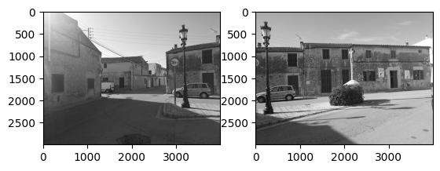

```python
img1 = cv2.imread("input/edifici1.jpg")
img2 = cv2.imread("input/edifici2.jpg")

img1_gray = cv2.cvtColor(img1, cv2.COLOR_BGR2GRAY)
img2_gray = cv2.cvtColor(img2, cv2.COLOR_BGR2GRAY)

plt.subplot(1,2,1)
plt.imshow(img1_gray, cmap="gray");

plt.subplot(1,2,2)
plt.imshow(img2_gray, cmap="gray");
```

### Exercise 1

Select four keypoints manually:

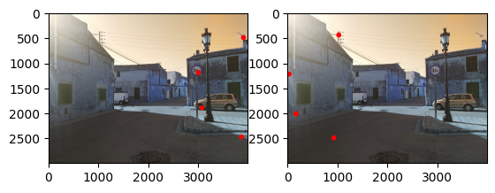

```python
points = [
    ((3900, 500), (1030, 450)),
    ((3000, 1200), (35, 1230)),
    ((3860, 2480), (930, 2500)),
    ((3070,1900), (175,2020))
]
img1_aux = img1.copy()
img2_aux = img1.copy()

for p1, p2 in points:
    cv2.circle(img1_aux, p1, radius = 50, color = (255,0,0), thickness=-1)
    cv2.circle(img2_aux, p2, radius = 50, color = (255,0,0), thickness=-1)

plt.subplot(1,2,1)
plt.imshow(img1_aux)

plt.subplot(1,2,2)
plt.imshow(img2_aux)
```

#### Homography

Once we have the 4 correspondent points let's do the homography of both images

- https://learnopencv.com/homography-examples-using-opencv-python-c/

```python
manual_keypoints1 = np.array([[3900, 500], [3000, 1200], [3860, 2480],[3070,1900]], dtype=np.float32)
manual_keypoints2 = np.array([[1030, 450], [35, 1230],[930, 2500],[175,2020]], dtype=np.float32)
print(f'kp1 = {manual_keypoints1.shape}, kp2 = {manual_keypoints2.shape}')
h, status = cv2.findHomography(manual_keypoints2,manual_keypoints1, cv2.RANSAC, 5.0)
```

```
kp1 = (4, 2), kp2 = (4, 2)
```

## *Warp* images

Finally, we convert the destination images to the origin image plane.

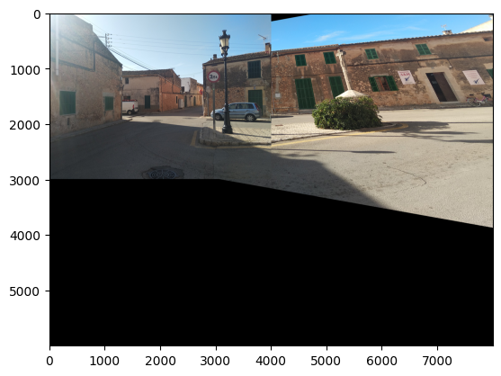

```python
wraped_img = cv2.warpPerspective(img2, h, (img1.shape[1] + img2.shape[1], img1.shape[0] + img2.shape[0]))
wraped_img[:img1.shape[0], :img1.shape[1]] = img1
plt.imshow(cv2.cvtColor(wraped_img, cv2.COLOR_BGR2RGB))
plt.show()
```

### Exercise 2

### Select a descriptor

In the next cell you must initialize a descriptor object (different of SIFT) as we have done previously:

```
{python}
sift = cv2.SIFT_create()

kp1, des1 = sift.detectAndCompute(img1,None)
kp2, des2 = sift.detectAndCompute(img2,None)
```

### Extract keys and descriptors

Extract keys and descriptors using OpenCV *common* module

# ORB

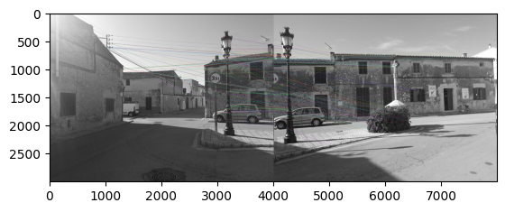

```python
orb = cv2.ORB_create() # Cream ORB descriptor

# Detect and compute
kp1, des1 = orb.detectAndCompute(img1_gray, None)
kp2, des2 = orb.detectAndCompute(img2_gray, None)

# Match descriptors
bf = cv2.BFMatcher(cv2.NORM_HAMMING, crossCheck=True)
matches = bf.match(des1, des2)
matched_img = cv2.drawMatches(img1_gray, kp1, img2_gray, kp2, matches, None)

plt.imshow(matched_img); #Visualisation
```

The displayed image is the output from the ORB feature matching algorithm. The lines represent the matched key points between the left and right images. ORB has identified several correspondences, indicating common features detected across both views. While there are numerous matches, some lines appear to cross over each other, which could imply potential mismatches or repetitive features in the images.

# BRISK

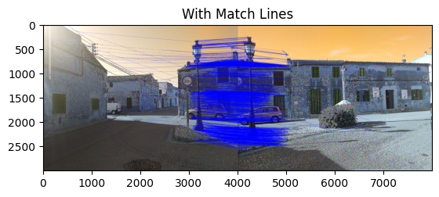

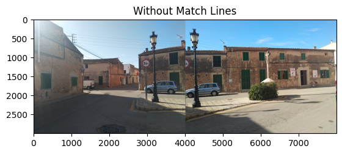

```python
br = cv2.BRISK_create()

kp1 = br.detect(img1, None) # Detect keypoints
kp2 = br.detect(img2, None)

# Compute descriptors
kp1, des1 = br.compute(img1, kp1)
kp2, des2 = br.compute(img2, kp2)

if des1 is not None and des2 is not None:

    bf = cv2.BFMatcher(cv2.NORM_HAMMING, crossCheck=False)

    # Find the top two matches for each descriptor
    matches = bf.knnMatch(des1, des2, k=2)
    points = []

    # Here I applied a ratio test to find the best matches
    for m,n in matches:
        if m.distance < 0.75 * n.distance:
            points.append([m])

    # Draw and visualisation with matches
    final_img = cv2.drawMatchesKnn(img1, kp1, img2, kp2, points, None, matchColor=(0,0,255), flags=cv2.DrawMatchesFlags_DEFAULT)
    plt.title('With Match Lines')
    plt.imshow(final_img)
    plt.show()

    # Same without matches
    plt.title('Without Match Lines')
    stitched_img = np.hstack((img1, img2))
    plt.imshow(cv2.cvtColor(stitched_img, cv2.COLOR_BGR2RGB))

else:
    print("Descriptors no trobats!!")
```

In the first image "With Match Lines," the blue lines indicate the correspondences between keypoints in the two scenes. BRISK has detected features in both images and attempted to find the best matches based on the binary descriptors it computes. The density of the blue lines in certain areas suggests that BRISK has identified several potential matches, particularly around structured elements in the scene, such as the building and the car.

However, the concentration of match lines also suggests that there may be a number of false positives, as indicated by the crisscrossing lines. This is typical when the algorithm detects repetitive patterns or textures that occur in multiple places within the images.

In the second image "Without Match Lines," we see the two original images stitched side-by-side for comparison without the distraction of the matching process. This provides a clear view of the scenes as they were captured, without any feature matching overlay.

The comparison between the two images allows us to appreciate how BRISK has performed.